# Assignment4

Callin Switzer

September 29, 2014

# 2a

kv26 <- c(5.79, 1579.52, 2323.70) kv28 <- c(68.8, 108.29, 110.29, 426.07, 1067.60)

y1 <- log(kv26) y2 <- log(kv28)

# 2b-d on other paper

# 2c. The antilog of the output from b is 1.3426

# 3

The following assumptions may not be met. 1. Independence might not be met, because the people who tend to be umps might not be fully independent. For instance, they umping might be more popular in certain parts of the US, where people are eating different diets – this could affect lifespan. 2. Homogeneity within the population might not be met, because it could similarly be affected by location. 3. The population isn’t normally distributed – in this case, we’re looking at the difference of the two groups (since we’re using a paired t-test). See the distributions below. Also, we haven’t randomly sampled from the population. Though these assumptions are not met, I will still go through with the analysis, using a paired t-test.

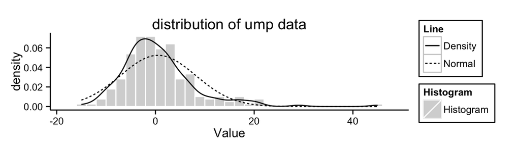

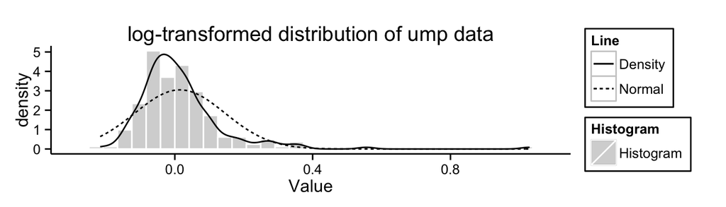

From the distributions, I don’t think a log transformation is appropriate. I’ve also tried other transformations, and I cannot find one that makes the data more normal. However, I will run the ttest with and without the oulier and see what happens.

# 3a

H0: Expected - Lifelength = 0 (i.e. umps have shorter lives than expected) HA: Expected - Lifelength > 0

According to our ttest with untransformed data, the one-sided pvalue is 0.1624, which means we fail to reject the null hypothesis that the umpire life lengths are shorter than expected.

I also reran the t-test, excluding the outlier, and found that the pvalue was 0.2675. This pvalue is still not significant, so we still fail to reject the null hypothesis.

# 3b

The potential consequences of ignoring the 212 of the 441 original umpires could have consequences. If we reanalyzed, using a different method, we might find a signifcant result. Ignoring half of the data could greatly throw off our conclusions. It probably gives us a sample that is not random, and probably not representative.

# 3c

Consequences of ignoring the censored data exist. We could analyze these data using a nonparametric test, and that may give us better insight. If we ignore the censored data, we may be biasing our sample – making it not representative of the population.

# 4ai

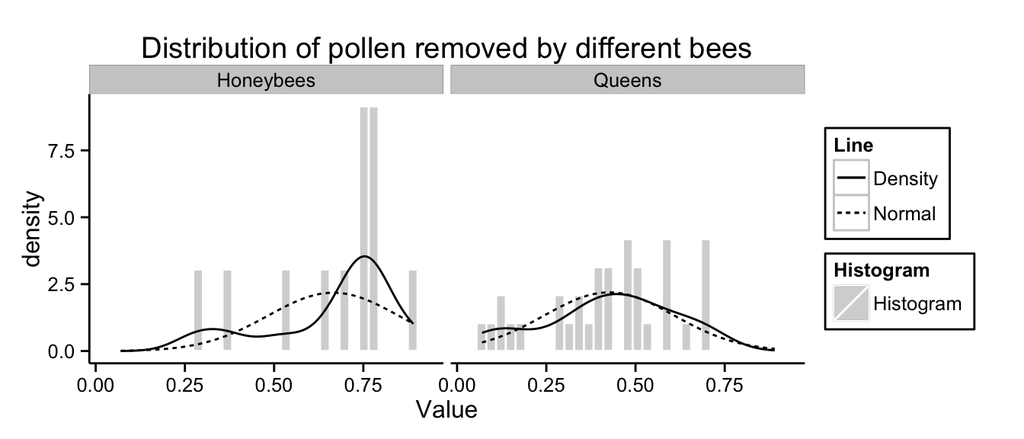

# 4aii

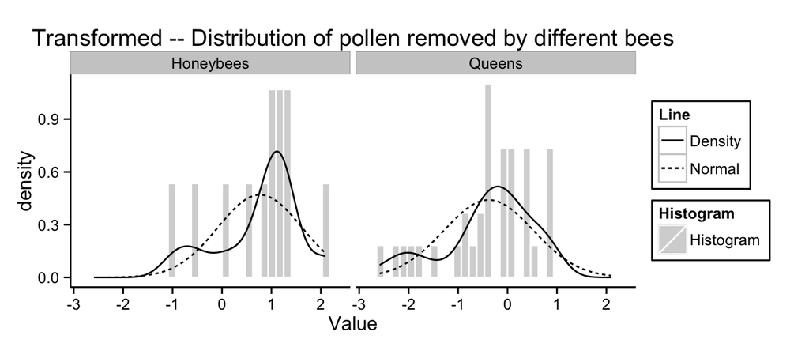

#4aiii

H0: The distributions of proportion removed is equal among the two bee types HA: The distributions of proportion removed is not equal among the two bee types

Since the ratio of variances is 1.1366, I will use a two-sample ttest with pooled variances. According to the ttest, the pvalue is 3.7151 × 10<sup>-4</sup>, which suggests that we reject H0.

# 4b

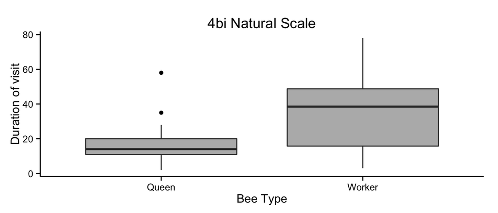

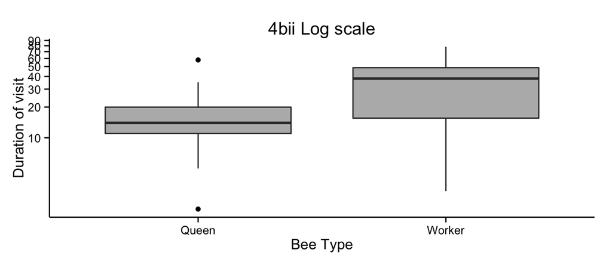

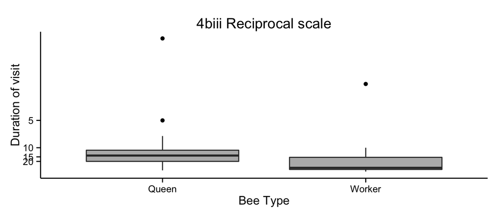